# Statistic_Project_FlorentinaVaniaS

### 2. b) Create a time plot of sales (Sales versus Time) and check if there are seasonal patterns. Examine evidence of seasonality visually. Describe the seasonality in your own words.

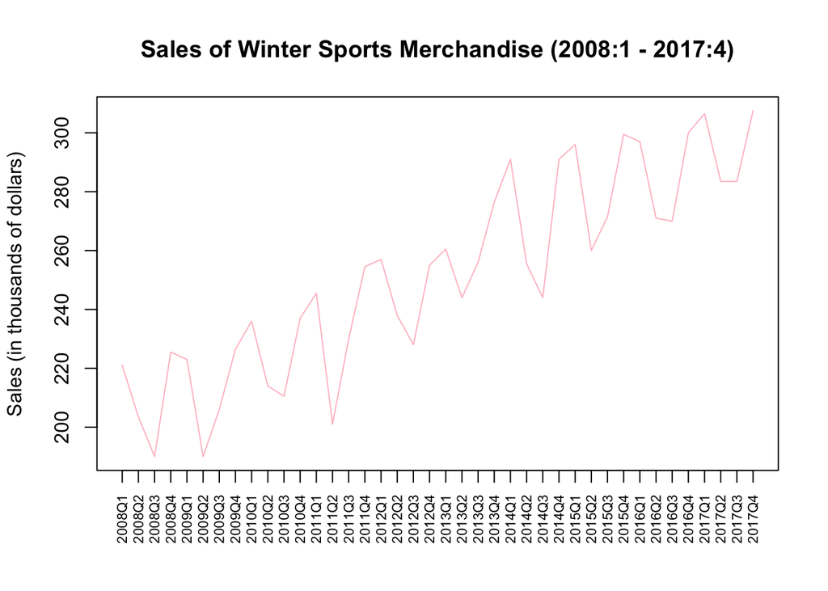

```r
# Create a new column that combines YEAR and QUARTER for detailed time labels
winterfun$DETAILED_TIME <- with(winterfun, paste(YEAR, "Q", QUARTER, sep=""))

# Plotting with more detailed time axis
plot(winterfun$TIME, winterfun$SALES, type='l', main='Sales of Winter Sports Merchandise (2008:1 - 2017:4)', xlab='', ylab='Sales (in thousands of dollars)', col='pink', xaxt='n') # Turn off x-axis labels

# Adding custom axis with detailed time labels
axis(1, at=winterfun$TIME, labels=winterfun$DETAILED_TIME, las=2, cex.axis=0.7)
```

```r
sprintf("DESCRIBE SEASONALITY: The plot shows peaks and troughs that seem to occur regularly each year, which is characteristic of seasonal variations. The peaks in sales occur at consistent intervals, which likely correspond to a particular time of the year (Q4-Q1). It would be reasonable to hypothesize that these peaks coincide with the winter months when demand for such merchandise would be higher. Similarly, the troughs or the lowest points in the sales data appear to happen with a regular frequency and are likely aligned with the off-season for winter sports, such as the summer months. Overall, the seasonality pattern indicated by the sales data suggests that there are certain times of the year with significantly higher sales, which for a winter sports company, are likely during the colder months when activities like skiing and ice skating are popular.")
```

```
## [1] "DESCRIBE SEASONALITY: The plot shows peaks and troughs that seem to occur regularly each year, which is characteristic of seasonal variations. The peaks in sales occur at consistent intervals, which likely correspond to a particular time of the year (Q4-Q1). It would be reasonable to hypothe…
```

### 2. c) Create indicator variables for quarters.

```r
## Create dummy variables
Q1_Dummy <- ifelse(winterfun$QUARTER == "1", 1, 0)
Q2_Dummy <- ifelse(winterfun$QUARTER == "2", 1, 0)
Q3_Dummy <- ifelse(winterfun$QUARTER == "3", 1, 0)
Q4_Dummy <- ifelse(winterfun$QUARTER == "4", 1, 0)
```

### 2. d) Conduct a Partial F-test to assess if the seasonal indicator variables are necessary in the model. Write the full model, the reduced models, and the hypotheses clearly. The reduced model in this case is the linear trend model and the full model is the one with indicator and the trend variables. Write your conclusion and interpretation. Compute the coefficient of partial determination and interpret it.

```r
chooseCRANmirror(graphics=FALSE, ind=1)  # Choose a CRAN mirror
install.packages('tinytex')
install.packages("greekLetters")
library(tinytex)
library(greekLetters)
options(scipen = 999)
full_model <- lm(SALES ~ TIME + Q1_Dummy + Q2_Dummy + Q3_Dummy + Q4_Dummy, data=winterfun)
summary(full_model)
```

```
##
## Call:
## lm(formula = SALES ~ TIME + Q1_Dummy + Q2_Dummy + Q3_Dummy +
##     Q4_Dummy, data = winterfun)
##
## Residuals:
##     Min      1Q  Median      3Q     Max
## -19.653  -4.478  -1.429   4.148  13.640
##
## Coefficients: (1 not defined because of singularities)
##              Estimate Std. Error t value             Pr(>|t|)
## (Intercept) 210.84583    3.14789  66.980 < 0.0000000000000002 ***
## TIME          2.56610    0.09895  25.932 < 0.0000000000000002 ***
## Q1_Dummy      3.74830    3.22927   1.161                0.254
## Q2_Dummy    -26.11780    3.22168  -8.107        0.00000000151 ***
## Q3_Dummy    -25.78390    3.21712  -8.015        0.00000000197 ***
## Q4_Dummy           NA         NA      NA                   NA
## ---
## Signif. codes:  0 '***' 0.001 '**' 0.01 '*' 0.05 '.' 0.1 ' ' 1
##
## Residual standard error: 7.19 on 35 degrees of freedom
## Multiple R-squared:  0.9593, Adjusted R-squared:  0.9546
## F-statistic: 206.1 on 4 and 35 DF,  p-value: < 0.00000000000000022
```

```r
drop_full_model <- lm(SALES ~ TIME + Q1_Dummy + Q2_Dummy + Q3_Dummy, data = winterfun)
summary(drop_full_model)
```

```
##
## Call:
## lm(formula = SALES ~ TIME + Q1_Dummy + Q2_Dummy + Q3_Dummy, data = winterfun)
##
## Residuals:
##     Min      1Q  Median      3Q     Max
## -19.653  -4.478  -1.429   4.148  13.640
##
## Coefficients:
##              Estimate Std. Error t value             Pr(>|t|)
## (Intercept) 210.84583    3.14789  66.980 < 0.0000000000000002 ***
## TIME          2.56610    0.09895  25.932 < 0.0000000000000002 ***
## Q1_Dummy      3.74830    3.22927   1.161                0.254
## Q2_Dummy    -26.11780    3.22168  -8.107        0.00000000151 ***
## Q3_Dummy    -25.78390    3.21712  -8.015        0.00000000197 ***
## ---
## Signif. codes:  0 '***' 0.001 '**' 0.01 '*' 0.05 '.' 0.1 ' ' 1
##
## Residual standard error: 7.19 on 35 degrees of freedom
## Multiple R-squared:  0.9593, Adjusted R-squared:  0.9546
## F-statistic: 206.1 on 4 and 35 DF,  p-value: < 0.00000000000000022
```

Full Model:SALES=210.84583+2.56610∗TIME+3.74830∗Q1−26.11780∗Q2−25.78390∗Q3+υReduced Model:SALES=199.017+2.556∗TIME+υ

```r
#Craft Hypotheses
paste(greeks("H_0"), ": The seasonal indicator variables (quarters) do not provide any additional information to the model.")
```

```
## [1] "H₀ : The seasonal indicator variables (quarters) do not provide any additional information to the model."
```

```r
paste(greeks("H_1"), ": The seasonal indicator variables do provide additional information to the model.")
```

```
## [1] "H₁ : The seasonal indicator variables do provide additional information to the model."
```

```r
#Conduct partial F-test
anova(trend_model, drop_full_model)
```

```
## Analysis of Variance Table
##
## Model 1: SALES ~ TIME
## Model 2: SALES ~ TIME + Q1_Dummy + Q2_Dummy + Q3_Dummy
##   Res.Df    RSS Df Sum of Sq      F             Pr(>F)
## 1     38 9622.1
## 2     35 1809.5  3    7812.6 50.371 0.0000000000008723 ***
## ---
## Signif. codes:  0 '***' 0.001 '**' 0.01 '*' 0.05 '.' 0.1 ' ' 1
```

```r
#CONCLUSION
sprintf("CONCLUSION & INTERPRETATION :  Based on the result, we have the low p-value  <0.05) and this would lead to reject the null hypothesis, indicating that the seasonal indicators are necessary in the model, therefore we can choose the full model as it significantly better.")
```

```
## [1] "CONCLUSION & INTERPRETATION :  Based on the result, we have the low p-value  <0.05) and this would lead to reject the null hypothesis, indicating that the seasonal indicators are necessary in the model, therefore we can choose the full model as it significantly better."
```

```r
#Compute the coefficient of partial determination

partial_R_squared = (0.9593 - 0.7835) / (1 - 0.7835)
partial_R_squared
```

```
## [1] 0.8120092
```

```r
print("INTERPRETATION of Coefficient of Partial Determination: This indicates that approximately 81.2% of the variation in sales that was not explained by the trend alone is explained by the addition of the seasonal indicators to the model.")
```

```
## [1] "INTERPRETATION of Coefficient of Partial Determination: This indicates that approximately 81.2% of the variation in sales that was not explained by the trend alone is explained by the addition of the seasonal indicators to the model."
```

## Question 3

### 3. a) Create a multiple regression model using Salary as the regressand and education level and gender as the regressors. For consistency, let’s use the Male dummy, although as you know, which dummy you use won’t matter.

```r
employmentdiscrimination <- read.csv("~/Desktop/VANIA/UC Davis 2023/Fall Semester/BAX 441 002 Statistic/Homework/Homework 4/EmploymentDiscrimination.csv")

Male_Dummy <- ifelse(employmentdiscrimination$GENDER == "MALE", 1, 0)

model_salary <- lm(SALARY ~ EDUCAT + Male_Dummy, data = employmentdiscrimination)
```

$$SALARY = 4173.13 + 80.70 *EDUCAT+691.81 *MaleDummy+\epsilon$$

```r
summary(model_salary)
```

```
##
## Call:
## lm(formula = SALARY ~ EDUCAT + Male_Dummy, data = employmentdiscrimination)
##
## Residuals:
##      Min       1Q   Median       3Q      Max
## -1241.50  -364.29    16.41   378.50  1943.90
##
## Coefficients:
##             Estimate Std. Error t value             Pr(>|t|)
## (Intercept)  4173.13     339.18  12.304 < 0.0000000000000002 ***
## EDUCAT         80.70      27.67   2.916              0.00447 **
## Male_Dummy    691.81     132.23   5.232           0.00000109 ***
## ---
## Signif. codes:  0 '***' 0.001 '**' 0.01 '*' 0.05 '.' 0.1 ' ' 1
##
## Residual standard error: 572.4 on 90 degrees of freedom
## Multiple R-squared:  0.3634, Adjusted R-squared:  0.3492
## F-statistic: 25.68 on 2 and 90 DF,  p-value: 0.000000001498
```

### 3. b) Interpret the differential intercept coefficient and the parameter estimate of the education level. Is there evidence of employment discrimination at the Harris bank?

```r
sprintf("INTERPRETATION: The intercept value indicates that, on average, the estimated mean salary for female employees, given the model’s variables, is approximately $4173.13. The Male dummy showing an additional $691.81 in salary for male employees compared to female employees when holding the education level constant, is statistically significant. The EDUCATION coefficient of 80.70 would represent the additional salary associated with each additional level of education, holding gender variable is constant. Meaning there is an evidence of employment discrimination at the Harris Bank where Male might have higher salary compare with female who has same education level, however we do need more further investigation before make any strong conclusion.")
```

```
## [1] "INTERPRETATION: The intercept value indicates that, on average, the estimated mean salary for female employees, given the model’s variables, is approximately $4173.13. The Male dummy showing an additional $691.81 in salary for male employees compared to female employees when holding the educ…
```

### 3. c) Does the difference in average salaries increase between two groups as education increases? Note: this question means that you want to test for the interaction between education and gender. An alternate formulation of the question is: Does the effect of gender on salary depend on the level of education? Create a new model to answer this question.

```r
### Use interaction
model_with_Interaction <- lm(SALARY ~ EDUCAT + Male_Dummy +
                                   EDUCAT:Male_Dummy, data = employmentdiscrimination)

summary(model_with_Interaction)
```

```
##
## Call:
## lm(formula = SALARY ~ EDUCAT + Male_Dummy + EDUCAT:Male_Dummy,
##     data = employmentdiscrimination)
##
## Residuals:
##      Min       1Q   Median       3Q      Max
## -1240.89  -349.06    72.72   372.72  1808.08
##
## Coefficients:
##                   Estimate Std. Error t value            Pr(>|t|)
## (Intercept)        4395.32     389.21  11.293 <0.0000000000000002 ***
## EDUCAT               62.13      31.94   1.945              0.0549 .
## Male_Dummy         -274.86     845.75  -0.325              0.7460
## EDUCAT:Male_Dummy    73.59      63.59   1.157              0.2503
## ---
## Signif. codes:  0 '***' 0.001 '**' 0.01 '*' 0.05 '.' 0.1 ' ' 1
##
## Residual standard error: 571.4 on 89 degrees of freedom
## Multiple R-squared:  0.3728, Adjusted R-squared:  0.3516
## F-statistic: 17.63 on 3 and 89 DF,  p-value: 0.000000004557
```

```r
### Check for the significance of interaction first
### H0: beta3 <= 0
### H1: beta3 > 0

sprintf("INTERPRETATION : p-value for the interaction is 0.2503 > alpha meaning that interaction is not significant. The effect of gender on salary does not depend on the level of education.")
```

```
## [1] "INTERPRETATION : p-value for the interaction is 0.2503 > alpha meaning that interaction is not significant. The effect of gender on salary does not depend on the level of education."
```